# Exploratory Data Analysis

Here are the details:

- Coverage from 1955–1997 for 18 Spanish regions. One of the data "regions" is all of Spain which we won't use.
- The treatment region is “Basque Country (Pais Vasco)”.
- The "treatment" year is 1975 since there were several bombings around that year.
- We will measure "economic impact" via GDP per capita (in thousands).

**Background:** Euskadi Ta Askatasuna (ETA), was an armed leftist Basque nationalist and separatist organization in the Basque Country (in northern Spain and southwestern France). The group was founded in 1959 and later evolved from a group promoting traditional Basque culture to a paramilitary group engaged in a violent campaign of bombing, assassinations and kidnappings in the Southern Basque Country and throughout Spanish territory. Its goal was gaining independence for the Basque Country. ETA was the main group within the Basque National Liberation Movement and was the most important Basque participant in the Basque conflict. While its terrorist activities spanned several decades, the death of Spanish dictator Francisco Franco in 1975 led to a substantial increase in bombings. (Wikipedia)

### Load Data

The data we want to access is from the following academic paper

> Abadie, A. and Gardeazabal, J. (2003) "Economic Costs of Conflict: A Case Study of the Basque Country." American Economic Review 93 (1) 113--132.

```python
import pyreadr
import pandas as pd
import matplotlib.pyplot as plt
import seaborn as sns
import numpy as np
```

```python
result = pyreadr.read_r('basque.RData')
data = result['basque'] # extract the pandas dataframe
data
```

| rownames | regionno | regionname | year | gdpcap | sec.agriculture | sec.energy | sec.industry | sec.construction | sec.services.venta | sec.services.nonventa | school.illit | school.prim | school.med | school.high | school.post.high | popdens | invest |
| --- | --- | --- | --- | --- | --- | --- | --- | --- | --- | --- | --- | --- | --- | --- | --- | --- | --- |
| 1 | 1.0 | Spain (Espana) | 1955.0 | 2.354542 | NaN | NaN | NaN | NaN | NaN | NaN | NaN | NaN | NaN | NaN | NaN | NaN | NaN |
| 2 | 1.0 | Spain (Espana) | 1956.0 | 2.480149 | NaN | NaN | NaN | NaN | NaN | NaN | NaN | NaN | NaN | NaN | NaN | NaN | NaN |
| 3 | 1.0 | Spain (Espana) | 1957.0 | 2.603613 | NaN | NaN | NaN | NaN | NaN | NaN | NaN | NaN | NaN | NaN | NaN | NaN | NaN |
| 4 | 1.0 | Spain (Espana) | 1958.0 | 2.637104 | NaN | NaN | NaN | NaN | NaN | NaN | NaN | NaN | NaN | NaN | NaN | NaN | NaN |
| 5 | 1.0 | Spain (Espana) | 1959.0 | 2.669880 | NaN | NaN | NaN | NaN | NaN | NaN | NaN | NaN | NaN | NaN | NaN | NaN | NaN |
| ... | ... | ... | ... | ... | ... | ... | ... | ... | ... | ... | ... | ... | ... | ... | ... | ... | ... |
| 770 | 18.0 | Rioja (La) | 1993.0 | 9.132391 | NaN | NaN | NaN | NaN | NaN | NaN | NaN | NaN | NaN | NaN | NaN | NaN | 16.765787 |
| 771 | 18.0 | Rioja (La) | 1994.0 | 9.498000 | NaN | NaN | NaN | NaN | NaN | NaN | NaN | NaN | NaN | NaN | NaN | NaN | 16.469452 |
| 772 | 18.0 | Rioja (La) | 1995.0 | 9.752213 | NaN | NaN | NaN | NaN | NaN | NaN | NaN | NaN | NaN | NaN | NaN | NaN | 20.275650 |
| 773 | 18.0 | Rioja (La) | 1996.0 | 10.056413 | NaN | NaN | NaN | NaN | NaN | NaN | NaN | NaN | NaN | NaN | NaN | NaN | NaN |
| 774 | 18.0 | Rioja (La) | 1997.0 | 10.476292 | NaN | NaN | NaN | NaN | NaN | NaN | NaN | NaN | NaN | NaN | NaN | NaN | NaN |

774 rows × 17 columns

### Drop Spain

Drop the region "Spain (Espana)".

```python
data.drop(data.loc[data['regionname']=='Spain (Espana)'].index, inplace=True)
```

### Plot GDP Per Capita Over Time

```python
basque = data[data['regionname']=='Basque Country (Pais Vasco)']
```

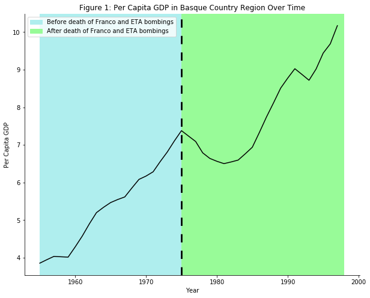

```python
import matplotlib.patches as mpatches
fig, ax = plt.subplots(figsize = (10,8))
ax.plot(basque['year'],basque['gdpcap'], color='black')
ax.set_xlabel('Year')
ax.set_ylabel('Per Capita GDP')
ax.set_title('Figure 1: Per Capita GDP in Basque Country Region Over Time')
ax.spines['right'].set_visible(False)
ax.spines['top'].set_visible(False)
ax.axvline(x=1975.0,color='black', linewidth = 2.75, dashes=[5,5])
ax.axvspan(1955.0,1975.0, facecolor = 'paleturquoise')
ax.axvspan(1975.0,1998.0, facecolor = 'palegreen')
pre = mpatches.Patch(color='paleturquoise', label = 'Before death of Franco and ETA bombings')
post = mpatches.Patch(color='palegreen', label = 'After death of Franco and ETA bombings')
plt.legend(handles=[pre,post])
```

We observe that per capita GDP decreases after the 1975 increase in ETA terrorist bombings and then increases. **How much of that decrease is due to terrorism and how much is due to general economic uncertainty from Franco's death?**

# Difference-in-Differences

### Comparing Before and After

We'll begin by comparing the per capit GDP before and after the 1975 treament year. Solve for average per capita GDP in the Basque region before (and including) 1975 to after 1975.

```python
basque_pre = basque[basque['year'] <= 1975.0]['gdpcap'].mean()
basque_post = basque[basque['year'] > 1975.0]['gdpcap'].mean()
print('Average Per Capita GDP Before (and including) 1975:',basque_pre)
print('Average Per Capita GDP After 1975:',basque_post)
print('Difference between AVG Per Capita GDP before and after:',basque_post-basque_pre)
```

```
Average Per Capita GDP Before (and including) 1975: 5.382258125349072
Average Per Capita GDP After 1975: 7.866706916492304
Difference between AVG Per Capita GDP before and after: 2.4844487911432322
```

### First-Difference Regression

We can evaluate the effect of the ETA is by constructing a "first difference" equation by having `gdpcap` as the dependent variable and adding a post indicator as an independent variable; i.e.,

$$\text{Per Capita GDP}_t = \beta_0 + \beta_1P_t + \epsilon_t$$

where $P_t$ is equal to one for all years after 1975 and zero otherwise.

```python
basque['period'] = (basque['year'] > 1975.0).astype(int)
```

```python
import statsmodels.formula.api as smf
```

```python
first_diff = smf.ols('gdpcap ~ period',data=basque).fit()
print(first_diff.summary())
```

```
                            OLS Regression Results
==============================================================================
Dep. Variable:                 gdpcap   R-squared:                       0.549
Model:                            OLS   Adj. R-squared:                  0.538
Method:                 Least Squares   F-statistic:                     49.92
Date:                Tue, 11 May 2021   Prob (F-statistic):           1.33e-08
Time:                        01:38:02   Log-Likelihood:                -66.097
No. Observations:                  43   AIC:                             136.2
Df Residuals:                      41   BIC:                             139.7
Df Model:                           1
Covariance Type:            nonrobust
==============================================================================
                 coef    std err          t      P>|t|      [0.025      0.975]
------------------------------------------------------------------------------
Intercept      5.3823      0.252     21.399      0.000       4.874       5.890
period         2.4844      0.352      7.065      0.000       1.774       3.195
==============================================================================
Omnibus:                       10.194   Durbin-Watson:                   0.171
Prob(Omnibus):                  0.006   Jarque-Bera (JB):                3.091
Skew:                           0.259   Prob(JB):                        0.213
Kurtosis:                       1.793   Cond. No.                         2.65
==============================================================================

Notes:
[1] Standard Errors assume that the covariance matrix of the errors is correctly specified.
```

## Difference-in-Differences (DiD)

We'll establish causality by comparing the trend of a "control" group to the Basque region. This is like conducting a an experiment where you give some patients a vaccine, drug, etc. while you give other patients a placebo. In that experimental setting, we design the experiment such that the control and treatment groups are identical but for the treament applied. We then observe whether or not outcomes-of-interest are significantly different between the two groups.

The same rationale holds here but of course we don't have an experimental setting so we choose a control group after the fact under the assumption this group provides an adequate proxy for the trend that would have been observed in the treatment group in the absence of treatment. if true, the difference in change of slope would be the actual treatment effect. Hence, the "difference in differences" terminology. **Note that our "identification strategy" requires the treatment and control groups follow the same pre-period (i.e., pre-treatment) trend which is something we can easilly show.**

In fact, we'll choose our control group using the following criteria:

1. High correlation between our control region's per capita GDP and the per capita GDP in the Basque country before 1975.
1. The control region is not located close to the Basque region. Implicitly, this criterion is based on our assumption that ETA bombings did not affect the control region's per capita GDP.

Solve for the correlation in per capita gdp between the differrent regions and the Basque country using only the pre-1975 period. Your output should be a table of correlations between per capita GDP of non-Basque regions (e.g., "Asturias") and the Basque region. Choose a control region which satisfies the above two criteria.

```python
data.regionname.unique()
```

```
array(['Andalucia', 'Aragon', 'Principado De Asturias',
       'Baleares (Islas)', 'Canarias', 'Cantabria', 'Castilla Y Leon',
       'Castilla-La Mancha', 'Cataluna', 'Comunidad Valenciana',
       'Extremadura', 'Galicia', 'Madrid (Comunidad De)',
       'Murcia (Region de)', 'Navarra (Comunidad Foral De)',
       'Basque Country (Pais Vasco)', 'Rioja (La)'], dtype=object)
```

```python
basque.reset_index(drop=True,inplace=True)
basque_pre_1975 = pd.DataFrame(basque[basque['year'] <= 1975.0]['gdpcap'])
andalucia = data[data['regionname']=='Andalucia']
andalucia = pd.DataFrame(andalucia[andalucia['year'] <= 1975.0]['gdpcap'])
andalucia.reset_index(drop=True,inplace=True)
basque_pre_1975.columns = ['Basque_gdp']
andalucia.columns = ['Andalucia_gdp']
aragon = data[data['regionname']=='Aragon']
aragon = pd.DataFrame(aragon[aragon['year'] <= 1975.0]['gdpcap'])
aragon.reset_index(drop=True,inplace=True)
aragon.columns = ['Aragon_gdp']
asturias = data[data['regionname']=='Principado De Asturias']
asturias = pd.DataFrame(asturias[asturias['year'] <= 1975.0]['gdpcap'])
asturias.reset_index(drop=True,inplace=True)
asturias.columns = ['Asturias_gdp']
balearas = data[data['regionname']=='Baleares (Islas)']
balearas = pd.DataFrame(balearas[balearas['year'] <= 1975.0]['gdpcap'])
balearas.reset_index(drop=True,inplace=True)
balearas.columns = ['Balearas_gdp']
canarias = data[data['regionname']=='Canarias']
canarias = pd.DataFrame(canarias[canarias['year'] <= 1975.0]['gdpcap'])
canarias.reset_index(drop=True,inplace=True)
canarias.columns = ['Canarias_gdp']
cantabria = data[data['regionname']=='Cantabria']
cantabria = pd.DataFrame(cantabria[cantabria['year'] <= 1975.0]['gdpcap'])
cantabria.reset_index(drop=True,inplace=True)
cantabria.columns = ['Cantabria_gdp']
castilla = data[data['regionname']=='Castilla Y Leon']
castilla = pd.DataFrame(castilla[castilla['year'] <= 1975.0]['gdpcap'])
castilla.reset_index(drop=True,inplace=True)
castilla.columns = ['Castilla_Y_Leon_gdp']
castilla_mancha = data[data['regionname']=='Castilla-La Mancha']
castilla_mancha = pd.DataFrame(castilla_mancha[castilla_mancha['year'] <= 1975.0]['gdpcap'])
castilla_mancha.reset_index(drop=True,inplace=True)
castilla_mancha.columns = ['Castilla_La_Mancha_gdp']
cataluna = data[data['regionname']=='Cataluna']
cataluna = pd.DataFrame(cataluna[cataluna['year'] <= 1975.0]['gdpcap'])
cataluna.reset_index(drop=True,inplace=True)
cataluna.columns = ['Cataluna_gdp']
valencia = data[data['regionname']=='Comunidad Valenciana']
valencia = pd.DataFrame(valencia[valencia['year'] <= 1975.0]['gdpcap'])
valencia.reset_index(drop=True,inplace=True)
valencia.columns = ['Valencia_gdp']
extremadura = data[data['regionname']=='Extremadura']
extremadura = pd.DataFrame(extremadura[extremadura['year'] <= 1975.0]['gdpcap'])
extremadura.reset_index(drop=True,inplace=True)
extremadura.columns = ['Extremadura_gdp']
galicia = data[data['regionname']=='Galicia']
galicia = pd.DataFrame(galicia[galicia['year'] <= 1975.0]['gdpcap'])
galicia.reset_index(drop=True,inplace=True)
galicia.columns = ['Galicia_gdp']
madrid = data[data['regionname']=='Madrid (Comunidad De)']
madrid = pd.DataFrame(madrid[madrid['year'] <= 1975.0]['gdpcap'])
madrid.reset_index(drop=True,inplace=True)
madrid.columns = ['Madrid_gdp']
murcia = data[data['regionname']=='Murcia (Region de)']
murcia = pd.DataFrame(murcia[murcia['year'] <= 1975.0]['gdpcap'])
murcia.reset_index(drop=True,inplace=True)
murcia.columns = ['Murcia_gdp']
navarra = data[data['regionname']=='Navarra (Comunidad Foral De)']
navarra = pd.DataFrame(navarra[navarra['year'] <= 1975.0]['gdpcap'])
navarra.reset_index(drop=True,inplace=True)
navarra.columns = ['Navarra_gdp']
rioja = data[data['regionname']=='Rioja (La)']
rioja = pd.DataFrame(rioja[rioja['year'] <= 1975.0]['gdpcap'])
rioja.reset_index(drop=True,inplace=True)
rioja.columns = ['Rioja_gdp']
df = pd.concat([basque_pre_1975,andalucia,aragon,asturias,balearas,canarias,cantabria,castilla,castilla_mancha,
               cataluna,valencia,extremadura,galicia,madrid,murcia,navarra,rioja],axis=1)
```

```python
corr = pd.DataFrame(df.corr())
sorted_corr = corr.sort_values(["Basque_gdp"], ascending=False)
sorted_corr['Basque_gdp']
#Aragon has a very slightly stronger correlation but Cataluna is much farther away from Basque Country.
#Cataluna is the best choice of control region.
```

```
Basque_gdp                1.000000
Aragon_gdp                0.997043
Cataluna_gdp              0.996830
Navarra_gdp               0.996262
Rioja_gdp                 0.995469
Asturias_gdp              0.995289
Cantabria_gdp             0.995258
Castilla_Y_Leon_gdp       0.992800
Murcia_gdp                0.991812
Valencia_gdp              0.991300
Madrid_gdp                0.988504
Balearas_gdp              0.987941
Andalucia_gdp             0.987689
Galicia_gdp               0.984275
Extremadura_gdp           0.984099
Castilla_La_Mancha_gdp    0.981486
Canarias_gdp              0.975647
Name: Basque_gdp, dtype: float64
```

Plot per capita GDP for the Basque country and your choice of control region (i.e., the region which best satisfies the above criteria).

```python
cataluna_df = data[data['regionname']=='Cataluna']
```

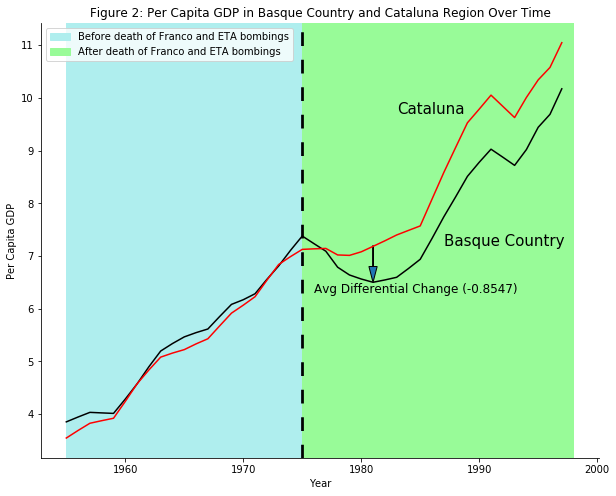

```python
fig, ax = plt.subplots(figsize = (10,8))
ax.plot(basque['year'],basque['gdpcap'], color='black', label = 'Basque Country')
ax.plot(cataluna_df['year'],cataluna_df['gdpcap'],color='red', label = 'Cataluna')
ax.set_xlabel('Year')
ax.set_ylabel('Per Capita GDP')
ax.set_title('Figure 2: Per Capita GDP in Basque Country and Cataluna Region Over Time')
ax.spines['right'].set_visible(False)
ax.spines['top'].set_visible(False)
ax.axvline(x=1975.0,color='black', linewidth = 2.75, dashes=[5,5])
ax.axvspan(1955.0,1975.0, facecolor = 'paleturquoise')
ax.axvspan(1975.0,1998.0, facecolor = 'palegreen')
ax.text(1983,9.7,'Cataluna',fontsize=15)
ax.text(1987,7.2,'Basque Country',fontsize=15)
ax.arrow(1981.0,7.2,0,-0.4, head_width = 0.7, head_length = 0.3)
ax.text(1976.0,6.3,'Avg Differential Change (-0.8547)', fontsize=12)
pre = mpatches.Patch(color='paleturquoise', label = 'Before death of Franco and ETA bombings')
post = mpatches.Patch(color='palegreen', label = 'After death of Franco and ETA bombings')
plt.legend(handles=[pre,post])
```

Run the following difference-in-differences regression:

$$\text{Per Capita GDP}_{it} = \beta_0 + \beta_1P_t + \beta_2T_i + \beta_3P_t\times T_i + \epsilon_t$$

where $P_t$ is the "period" indicator equal to one for all years after 1975 and zero otherwise; $T_i$ is the "treatment" group indicator equal to one when the region is the Basque region; and $i$ is the region. Note the regression only uses observations from the treatment (Basque region) and control group.

```python
cataluna_df['period'] = (cataluna_df['year'] > 1975.0).astype(int)
```

```python
did_df = pd.concat([basque,cataluna_df],axis=0)
did_df['treatment'] = (did_df['regionname']=='Basque Country (Pais Vasco)').astype(int)
```

```python
second_diff = smf.ols('gdpcap ~ period*treatment',data=did_df).fit()
print(second_diff.summary())
```

```
                            OLS Regression Results
==============================================================================
Dep. Variable:                 gdpcap   R-squared:                       0.607
Model:                            OLS   Adj. R-squared:                  0.593
Method:                 Least Squares   F-statistic:                     42.28
Date:                Tue, 11 May 2021   Prob (F-statistic):           1.29e-16
Time:                        01:38:47   Log-Likelihood:                -136.91
No. Observations:                  86   AIC:                             281.8
Df Residuals:                      82   BIC:                             291.6
Df Model:                           3
Covariance Type:            nonrobust
====================================================================================
                       coef    std err          t      P>|t|      [0.025      0.975]
------------------------------------------------------------------------------------
Intercept            5.2436      0.266     19.735      0.000       4.715       5.772
period               3.3392      0.371      8.989      0.000       2.600       4.078
treatment            0.1387      0.376      0.369      0.713      -0.609       0.886
period:treatment    -0.8547      0.525     -1.627      0.108      -1.900       0.190
==============================================================================
Omnibus:                       38.183   Durbin-Watson:                   0.321
Prob(Omnibus):                  0.000   Jarque-Bera (JB):                6.512
Skew:                           0.223   Prob(JB):                       0.0385
Kurtosis:                       1.728   Cond. No.                         6.93
==============================================================================

Notes:
[1] Standard Errors assume that the covariance matrix of the errors is correctly specified.
```

Discuss the results. The interpretation of the coefficients is:

**Our interest is $\beta_3$**. For you visual learners, the following image will give you some intuition as to how to interpret the results (and why this is called difference-in-differences):

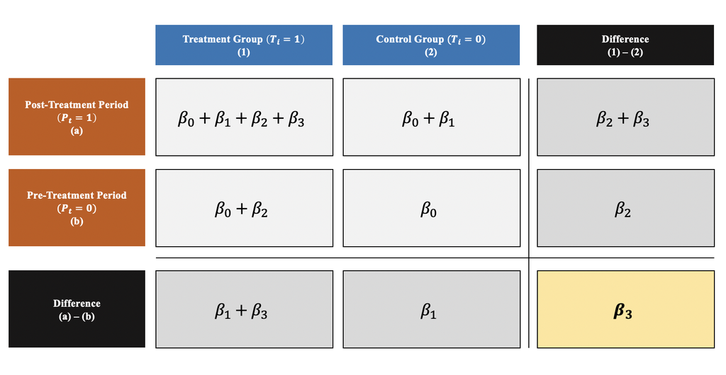

For this DiD analysis, the control region was identified using the correlation in GDP per capita between the different regions prior to the bombings in 1975. Although Aragon had a slightly higher correlation in gdp per capita with the Basque Country, Cataluna was better choice for using as a control region because it is further away from the Basque Country and wouldn't be as affected by the bombings as Aragon would be. Looking at the coefficient of estimate for the interaction between the treatment and period variables, the per capita GDP in the Basque Country reduced by 0.8547 because of the terrorist intervention. The average per capita GDP decreased by 0.8547 from before the bombings to after the bombings in the Basque country, relative to the Cataluna region.

# Synthetic Control

The "synthetic control" (aka synthetic difference-in-differneces) method allows for estimation in settings where a single unit (a state, country, firm, etc.) is exposed to an event or intervention but it's not obvious who or what the control group should be. Specifically, synthetic control provides a data-driven procedure to construct a control group using a convex combination of comparison units. The idea is that this generated (ie, synthetic) control group approximates the characteristics of the unit of interest prior to treatment. The thought (hope) is that a combination of comparison units provides a better comparison for the unit exposed to the intervention than any single comparison unit.

In our example above, we identfied a control variable by generating a metric to assess pre-period trends. In many (most?) cases, we will have too much data to identify a control group by "eyeballing" the data and we'll likely not be able to satisfy the parallel trend pre-period assumption. What if instead we could create a control group via a convex combination of potential candidates? That's the idea behind "synthetic controls" -- we create a control group.

Synthetic control is a technique which is very similar to DiD in estimating the true impact of a treatment. Both the methods use the help of control groups to construct a counter-factual of the treated group giving us an idea of what the trend is if the treatment had not happened. The counter-factual GDP of the treated group would be predicted by the GDP of the control groups and also other possible covariates in the control group.

Just as the DiD approach used the control to construct a counter-factual of the treated group giving us an idea of what the trend is if the treatment had not happened, "synthetic control" predicts the counter-factual by assigning weights to the regressors in the control groups identify individual regressors and their influence in prediction. Ultimately, the true causal impact is the difference in GDP between actual GDP and the counter-factual GDP if the treatment had not happened which is the same idea as DiD.

### Visualization

```python
data.regionname.unique()
```

```
array(['Andalucia', 'Aragon', 'Principado De Asturias',
       'Baleares (Islas)', 'Canarias', 'Cantabria', 'Castilla Y Leon',
       'Castilla-La Mancha', 'Cataluna', 'Comunidad Valenciana',
       'Extremadura', 'Galicia', 'Madrid (Comunidad De)',
       'Murcia (Region de)', 'Navarra (Comunidad Foral De)',
       'Basque Country (Pais Vasco)', 'Rioja (La)'], dtype=object)
```

```python
andalucia_df = data[data['regionname']=='Andalucia']
aragon_df = data[data['regionname']=='Aragon']
asturias_df = data[data['regionname']=='Principado De Asturias']
balearas_df = data[data['regionname']=='Baleares (Islas)']
canarias_df = data[data['regionname']=='Canarias']
cantabria_df = data[data['regionname']=='Cantabria']
castilla_df = data[data['regionname']=='Castilla Y Leon']
castilla_mancha_df = data[data['regionname']=='Castilla-La Mancha']
valencia_df = data[data['regionname']=='Comunidad Valenciana']
extremedura_df = data[data['regionname']=='Extremadura']
galicia_df = data[data['regionname']=='Galicia']
madrid_df = data[data['regionname']=='Madrid (Comunidad De)']
murcia_df = data[data['regionname']=='Murcia (Region de)']
navarra_df = data[data['regionname']=='Navarra (Comunidad Foral De)']
rioja_df = data[data['regionname']=='Rioja (La)']
```

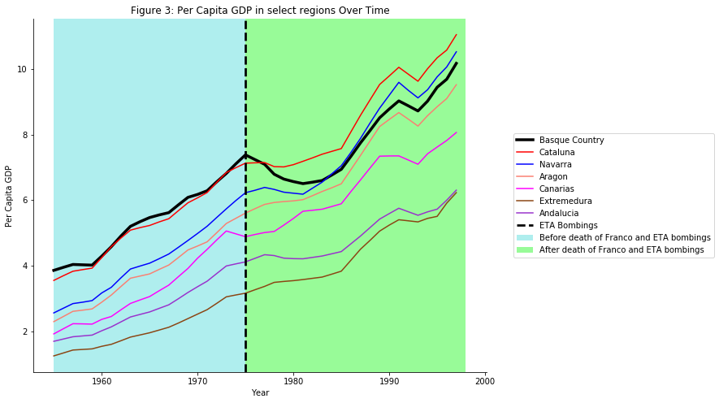

```python
fig, ax = plt.subplots(figsize = (10,8))
ax.plot(basque['year'],basque['gdpcap'], color='black', label = 'Basque Country',linewidth = 3.50)
ax.plot(cataluna_df['year'],cataluna_df['gdpcap'],color='red', label = 'Cataluna')
ax.plot(navarra_df['year'],navarra_df['gdpcap'],color='blue', label = 'Navarra')
ax.plot(aragon_df['year'],aragon_df['gdpcap'],color='salmon', label = 'Aragon')
ax.plot(canarias_df['year'],canarias_df['gdpcap'],color='magenta', label = 'Canarias')
ax.plot(extremedura_df['year'],extremedura_df['gdpcap'],color='saddlebrown', label = 'Extremedura')
ax.plot(andalucia_df['year'],andalucia_df['gdpcap'],color='darkorchid', label = 'Andalucia')
ax.set_xlabel('Year')
ax.set_ylabel('Per Capita GDP')
ax.set_title('Figure 3: Per Capita GDP in select regions Over Time')
ax.spines['right'].set_visible(False)
ax.spines['top'].set_visible(False)
ax.axvline(x=1975.0,color='black', linewidth = 2.75, linestyle = '--', label = 'ETA Bombings')
ax.axvspan(1955.0,1975.0, facecolor = 'paleturquoise',label='Before death of Franco and ETA bombings')
ax.axvspan(1975.0,1998.0, facecolor = 'palegreen',label='After death of Franco and ETA bombings')
ax.legend(bbox_to_anchor=(1.05,0.5),loc='center left')
```

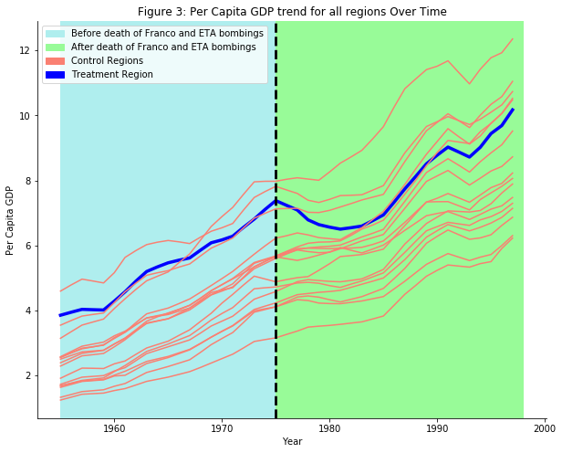

```python
fig, ax = plt.subplots(figsize = (10,8))
ax.plot(basque['year'],basque['gdpcap'], color='blue', label = 'Treated',linewidth = 3.50)
ax.plot(cataluna_df['year'],cataluna_df['gdpcap'],color='salmon', label = 'Control')
ax.plot(navarra_df['year'],navarra_df['gdpcap'],color='salmon', label = 'Control')
ax.plot(aragon_df['year'],aragon_df['gdpcap'],color='salmon', label = 'Control')
ax.plot(canarias_df['year'],canarias_df['gdpcap'],color='salmon', label = 'Control')
ax.plot(extremedura_df['year'],extremedura_df['gdpcap'],color='salmon', label = 'Control')
ax.plot(andalucia_df['year'],andalucia_df['gdpcap'],color='salmon', label = 'Control')
ax.plot(asturias_df['year'],asturias_df['gdpcap'],color='salmon', label = 'Control')
ax.plot(balearas_df['year'],balearas_df['gdpcap'],color='salmon', label = 'Control')
ax.plot(cantabria_df['year'],cantabria_df['gdpcap'],color='salmon', label = 'Control')
ax.plot(castilla_df['year'],castilla_df['gdpcap'],color='salmon', label = 'Control')
ax.plot(castilla_mancha_df['year'],castilla_mancha_df['gdpcap'],color='salmon', label = 'Control')
ax.plot(valencia_df['year'],valencia_df['gdpcap'],color='salmon', label = 'Control')
ax.plot(galicia_df['year'],galicia_df['gdpcap'],color='salmon', label = 'Control')
ax.plot(madrid_df['year'],madrid_df['gdpcap'],color='salmon', label = 'Control')
ax.plot(murcia_df['year'],murcia_df['gdpcap'],color='salmon', label = 'Control')
ax.plot(rioja_df['year'],rioja_df['gdpcap'],color='salmon', label = 'Control')
ax.set_xlabel('Year')
ax.set_ylabel('Per Capita GDP')
ax.set_title('Figure 3: Per Capita GDP trend for all regions Over Time')
ax.spines['right'].set_visible(False)
ax.spines['top'].set_visible(False)
ax.axvline(x=1975.0,color='black', linewidth = 2.75, linestyle = '--', label = 'ETA Bombings')
ax.axvspan(1955.0,1975.0, facecolor = 'paleturquoise',label='Before death of Franco and ETA bombings')
ax.axvspan(1975.0,1998.0, facecolor = 'palegreen',label='After death of Franco and ETA bombings')
pre = mpatches.Patch(color='paleturquoise', label = 'Before death of Franco and ETA bombings')
post = mpatches.Patch(color='palegreen', label = 'After death of Franco and ETA bombings')
control = mpatches.Patch(color='salmon',label = 'Control Regions')
treatment = mpatches.Patch(color='blue',label = 'Treatment Region')
plt.legend(handles=[pre,post,control,treatment])
```

**Idea:** What we'll be doing is picking the convex combination of regions to best match the evolution of per capita GDP prior to the ETA bombings (i.e., before 1975). We'll then hold these weights fixed and generate per capita GDP for the synthetic post-treatment control group. That's it. Identifying the causal effect then follows our DiD regression where we use the synthetic control rather than a specific control. A nice feature of this approach is that we can be hands-off in selection of our control group. Plus, construction of our synthetical control is not based on the treatment period so there's minimal risk of inadvertantly baking-in our results.

### Construct a Synthetic Control Group

```python
data_pre_1975 = pd.DataFrame(data[data['year'] <= 1975.0])
#drop regions that border the Basque Country
data_pre_1975 = data_pre_1975[~data_pre_1975['regionname'].isin(['Rioja (La)','Navarra (Comunidad Foral De)','Cantabria','Castilla Y Leon'])]
inverted = (data_pre_1975.pivot(index='regionname', columns="year")['gdpcap']
            .T)
```

```python
from sklearn.linear_model import LassoCV
```

```python
y = inverted['Basque Country (Pais Vasco)'].values
X = inverted.drop(columns='Basque Country (Pais Vasco)').values
```

```python
lasso_model = LassoCV(fit_intercept=False,cv=10).fit(X,y)
```

Use the model to generate (predict) a control group for all the years.

```python
data_2 = data[~data['regionname'].isin(['Rioja (La)','Navarra (Comunidad Foral De)','Cantabria','Castilla Y Leon','Basque Country (Pais Vasco)'])]
```

```python
weights = lasso_model.coef_
synth_control = (data_2
                  .pivot(index='year', columns="regionname")["gdpcap"]
                  .values.dot(weights))
```

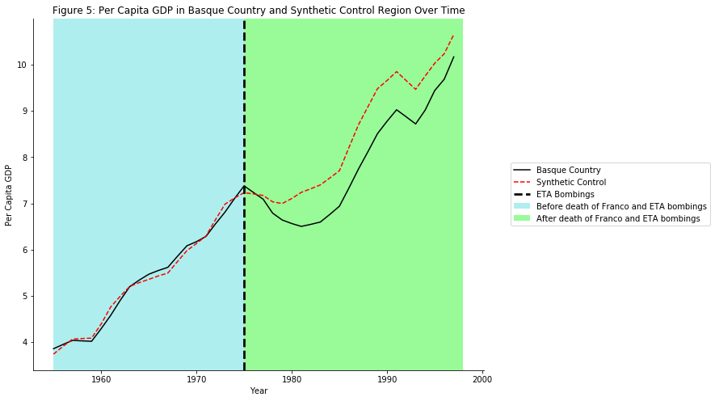

```python
fig, ax = plt.subplots(figsize = (10,8))
ax.plot(basque['year'],basque['gdpcap'], color='black',label = 'Basque Country')
ax.plot(basque['year'],synth_control, color='red', label = 'Synthetic Control', linestyle = '--')
ax.set_xlabel('Year')
ax.set_ylabel('Per Capita GDP')
ax.set_title('Figure 5: Per Capita GDP in Basque Country and Synthetic Control Region Over Time')
ax.spines['right'].set_visible(False)
ax.spines['top'].set_visible(False)
ax.axvline(x=1975.0,color='black', linewidth = 2.75, linestyle = '--', label = 'ETA Bombings')
ax.axvspan(1955.0,1975.0, facecolor = 'paleturquoise', label='Before death of Franco and ETA bombings')
ax.axvspan(1975.0,1998.0, facecolor = 'palegreen', label='After death of Franco and ETA bombings')
ax.legend(bbox_to_anchor=(1.05,0.5),loc='center left')
```

### Synthetic Difference-in-Differences

Run the following synthetic difference-in-differences regression:

$$\text{Per Capita GDP}_{it} = \beta_0 + \beta_1P_t + \beta_2T_i + \beta_3P_t\times T_i + \epsilon_t$$

where $P_t$ is the "period" indicator equal to one for all years after 1975 and zero otherwise; $T_i$ is the "treatment" group indicator equal to one when the region is the Basque region; and $i$ is the region.

```python
years = np.arange(1955.0,1998.0,1).tolist()
d = {'regionname':'Synthetic','gdpcap':synth_control,'year':years}
synth_df = pd.DataFrame(d)
basque_2 = basque[['regionname', 'gdpcap','year']]
synth_df2 = pd.concat([basque_2,synth_df],axis=0)
synth_df2['period'] = (synth_df2['year'] > 1975.0).astype(int)
synth_df2['treatment'] = (synth_df2['regionname']=='Basque Country (Pais Vasco)').astype(int)
```

```python
synth_did = smf.ols('gdpcap ~ period*treatment',data=synth_df2).fit()
print(synth_did.summary())
```

```
                            OLS Regression Results
==============================================================================
Dep. Variable:                 gdpcap   R-squared:                       0.609
Model:                            OLS   Adj. R-squared:                  0.595
Method:                 Least Squares   F-statistic:                     42.55
Date:                Tue, 11 May 2021   Prob (F-statistic):           1.11e-16
Time:                        01:40:02   Log-Likelihood:                -133.61
No. Observations:                  86   AIC:                             275.2
Df Residuals:                      82   BIC:                             285.0
Df Model:                           3
Covariance Type:            nonrobust
====================================================================================
                       coef    std err          t      P>|t|      [0.025      0.975]
------------------------------------------------------------------------------------
Intercept            5.3743      0.256     21.020      0.000       4.866       5.883
period               3.1489      0.357      8.809      0.000       2.438       3.860
treatment            0.0080      0.362      0.022      0.982      -0.711       0.727
period:treatment    -0.6645      0.506     -1.314      0.192      -1.670       0.341
==============================================================================
Omnibus:                       43.404   Durbin-Watson:                   0.331
Prob(Omnibus):                  0.000   Jarque-Bera (JB):                6.628
Skew:                           0.200   Prob(JB):                       0.0364
Kurtosis:                       1.700   Cond. No.                         6.93
==============================================================================

Notes:
[1] Standard Errors assume that the covariance matrix of the errors is correctly specified.
```

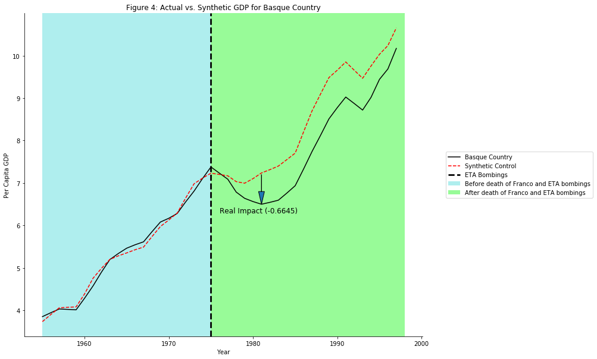

```python
fig, ax = plt.subplots(figsize = (12,10))
ax.plot(basque['year'],basque['gdpcap'], color='black',label = 'Basque Country')
ax.plot(basque['year'],synth_control, color='red', label = 'Synthetic Control', linestyle = '--')
ax.set_xlabel('Year')
ax.set_ylabel('Per Capita GDP')
ax.set_title('Figure 4: Actual vs. Synthetic GDP for Basque Country')
ax.spines['right'].set_visible(False)
ax.spines['top'].set_visible(False)
ax.axvline(x=1975.0,color='black', linewidth = 2.75, linestyle = '--', label = 'ETA Bombings')
ax.axvspan(1955.0,1975.0, facecolor = 'paleturquoise', label='Before death of Franco and ETA bombings')
ax.axvspan(1975.0,1998.0, facecolor = 'palegreen', label='After death of Franco and ETA bombings')
ax.arrow(1981.0,7.2,0,-0.4, head_width = 0.7, head_length = 0.3)
ax.text(1976.0,6.3,'Real Impact (-0.6645)', fontsize=12)
ax.legend(bbox_to_anchor=(1.05,0.5),loc='center left')
```

```python
params = pd.DataFrame({'First-Difference Regression':first_diff.params[1:],'Difference-in-Differences Regression':
                      second_diff.params[1:],'Synthetic Difference-in-Differences': synth_did.params[1:]},index =
                     ['period','treatment','period:treatment'])
params
```

|  | First-Difference Regression | Difference-in-Differences Regression | Synthetic Difference-in-Differences |
| --- | --- | --- | --- |
| period | 2.484449 | 3.339185 | 3.148926 |
| treatment | NaN | 0.138678 | 0.007987 |
| period:treatment | NaN | -0.854736 | -0.664477 |